# Environmental Gentrification - INLA Analysis Overview

Joyce Hu

2025-4-18

# Project overview

## Gentrification and Environmental Change in New York City

This project examines the relationship between gentrification and environmental changes in New York City between 2000 and 2016, investigating whether census tracts experiencing higher levels of gentrification are associated with patterns of environmental improvement or degradation.

Although gentrification has been differentially conceptualized in the literature, it is broadly recognized as the process where wealthier populations enter a neighborhood of historical disinvestment, contributing to the displacement of existing residents via increasing prices of housing, goods, services. In analyses, the following characteristics are often linked to gentrification: capital reinvestment in previously disinvested neighborhoods, demographic shifts with influx of higher-income residents, physical landscape transformation, changes in commercial services and amenities.

Green or environmental gentrification is the idea that initiatives and policies seeking to improve environmental conditions (e.g., urban greening like parks and street trees, air pollution and brownfield site remediation) may contribute to, or in some cases even drive, gentrification e.g., driving up the housing prices in a neighborhood. This has implications for environmental and health justice. For example, urban green space is associated with improved mental health and increased physical activity but if greening initiatives also contribute to gentrification, existing residents may not experience these health benefits.

The first research question we seek to answer with this project is, “does environmental gentrification impact New York City?” More specifically, do areas undergoing gentrification experience different environmental changes compared to non-gentrifying areas?

We use a census tract-level index of gentrification (Johnson et al., 2021) as the independent variable and examines its relationship with several environmental factors (dependent variables): Air quality indicators (PM2.5,O3, NO2), vegetation measured through NDVI - Normalized Difference Vegetation Index, mean temperature in 2016.

We hypothesize that NYC census tracts with higher gentrification levels between 2000-2016 will be associated with: decreased concentrations of PM2.5 and NO2, increased vegetation (higher NDVI values), smaller increases in ozone (O3) concentrations, lower mean temperatures

This analysis informs the basis of a second part he project which evaluates the relationship between environmental gentrification (as a combined exposure) and the change in prevalence of health-relevant endpoints.

# Load packages

```r
library(tidyverse)
library(here)
library(arrow)          # Reading parquet files
library(readxl)         # Reading excel files
library(tidycensus)     # Census data access
library(tigris)         # Census tract boundaries
library(terra)          # Raster processing
library(exactextractr)  # Raster aerial interpolation
library(tidyterra)      # For terra objects in tidyverse
library(sf)             # Spatial data
library(spdep)          # Spatial dependence tests
library(spatialreg)     # Spatial regression models
library(INLA)           # Integrated nested laplace approximation models

# Unused packages for this code (keeping for now)
# library(mgcv) library(fixest) library(lmtest) library(mgcViz) library(DHARMa) library(qqplotr)
# library(lattice)library(distr) #for qqbounds()
# library(gridExtra) library(qgam)  library(ggfields) # for plotting spatial field
# library(ggregplot) #INLA compatible plotting library (efxplot)
# library(kableExtra)library(inlatools) # for INLA diagnostics
```

# Data acquisition and processing

This section loads and prepares all the necessary datasets for analysis. We combine NYC census tract boundaries with: 1. Gentrification scores (2000-2016) sourced from [Johnson et al.’s (2021) gentrifiction index](https://doi.org/10.1080/13658816.2021.1931873) 2. Air pollutant measures (PM2.5, NO2, O3) 3. Normalized Difference Vegetation Index (NDVI) as the measure of vegetative greening 4. Temperature data (not used in final analysis) 5. Median income

```r
# Check if 'data' directory exists; if not, create it
if (!dir.exists(here("data"))) {
  dir.create(here("data"))
}

# Load gentrification score by tract
gentrification <- read.csv(here("data", "Data_NYC_Gentrification_2000_16.csv")) %>%
  mutate(tractid = as.character(tractid)) %>%
  dplyr::select(tractid, score_0.5)

# Load gentrification score if using xlsx file:
# gentrification <- read_xlsx(here("Gentrification","Data_NYC_Gentrification_2000_16.xlsx")) %>%
#   mutate(tractid = as.character(tractid)) %>%
#   dplyr::select(tractid, score_0.5)

# Pull NYC tract IDs/fips from gentrification index dataset for filtering
nyc_fips <- gentrification$tractid

# Load NYC tracts shapefile
nyc_tracts <- tracts(state = "NY", county = c("Bronx", "Kings", "New York", "Queens", "Richmond"), year = 2010) %>%
  # clean lat and long for Conley SEs
  mutate(lat = as.numeric(INTPTLAT10), long = as.numeric(INTPTLON10), GEOID = GEOID10) %>%
  # filter for FIPS codes included in gentrification index dataset
  filter(GEOID %in% nyc_fips)


# Load NY tracts populatuion weighted centroid points from Census data
nyc_weighted_centroids <- read.table("https://www2.census.gov/geo/docs/reference/cenpop2010/tract/CenPop2010_Mean_TR36.txt",
                         header = TRUE, sep = ",", stringsAsFactors = FALSE,
                         colClasses = c("character", "character", "character", "numeric", "numeric", "numeric")) %>%
  mutate(FIPS = paste(STATEFP, COUNTYFP, TRACTCE, sep = "")) %>%
  ## filter for only NYC tracts
  filter(FIPS %in% nyc_fips) %>%
  rename(Longitude_weighted = LONGITUDE,
         Latitude_weighted = LATITUDE)

# JH - 10/12/24 warning persists 10/13, 10/14 Warning: R metadata may have unsafe or invalid elements ℹ Type: "externalptr" options(arrow.unsafe_metadata = TRUE) #

# Temperature data
if(!file.exists(here("data","summarized_daily_temp_preds.parquet"))){download.file("https://zenodo.org/records/10557980/files/summarized_daily_temp_preds.parquet?download=1",
                                                                                   destfile = here("data","summarized_daily_temp_preds.parquet"))}

# Temperature by tract
temp <- read_parquet(here("data","summarized_daily_temp_preds.parquet")) %>%
  filter(str_detect(date, "2016")) %>%
  mutate(temp_c = mean_temp_daily_cK/100-273.15) %>%
  mutate(temp_f = temp_c*9/5+32) %>%
  group_by(GEOID, date) %>%
  ungroup() %>%
  group_by(GEOID) %>%
  summarize(mean_temp = mean(mean_temp_daily_cK/100))

# NDVI by tract (need to have it downloaded and stored locally)
ndvi_mean_2016 <- rast(here("data", "ndvi_c2_2016_2.tif")) %>%
  exact_extract(nyc_tracts, fun = "mean")

ndvi_mean_2000 <- rast(here("data", "ndvi_c2_2000_2.tif")) %>%
  exact_extract(nyc_tracts, fun = "mean")

ndvi_sd_2016 <- rast(here("data", "ndvi_c2_2000_2.tif")) %>%
  exact_extract(nyc_tracts, fun = "stdev")

ndvi_sd_2000 <- rast(here("data", "ndvi_c2_2016_2.tif")) %>%
  exact_extract(nyc_tracts, fun = "stdev")

# PM2.5 data
# Download data from URL
download_data <- function() {
  # set longer timeout
  options(timeout = 7200)
  if(!file.exists(here("data", "2016_pm25_daily_average.txt.gz"))){download.file("https://ofmpub.epa.gov/rsig/rsigserver?data/FAQSD/outputs/2016_pm25_daily_average.txt.gz", destfile = here("data", "2016_pm25_daily_average.txt.gz"))} #2016
  if(!file.exists(here("data", "2002_pm25_daily_average.txt.gz"))){download.file("https://ofmpub.epa.gov/rsig/rsigserver?data/FAQSD/outputs/2002_pm25_daily_average.txt.gz", destfile = here("data", "2002_pm25_daily_average.txt.gz"))}} #2002
download_data()

# Read in PM2.5 daily average by census tract from EPA FAQSD - 2002
pm_tract_2002 <- read.delim(gzfile(here("data", "2002_pm25_daily_average.txt.gz")), sep = ",") %>%
  ## Include only NYC tracts
  filter(FIPS %in% nyc_fips) %>%
  ## Convert FIPS to character for compatibility
  mutate(FIPS = as.character(FIPS)) %>%
  ## Join with population-weighted centroids
  left_join(nyc_weighted_centroids, by = "FIPS") %>%
  ## Calculate annual average by tract using population weighted centroid
  group_by(FIPS) %>%
  summarize(pm_mean_2002 = mean(pm25_daily_average.ug.m3.),
            pm_sd_2002 = sd(pm25_daily_average.ug.m3.),
            Longitude = first(Longitude_weighted),
            Latitude = first(Latitude_weighted))

# Read in PM2.5 daily average by census tract from EPA FAQSD - 2016
pm_tract_2016 <- read.delim(gzfile(here("data", "2016_pm25_daily_average.txt.gz")), sep = ",") %>%
  ## include only NYC tracts
  filter(Loc_Label1 %in% nyc_fips) %>%
  ## Convert Loc_Label1 to character for compatibility
  mutate(Loc_Label1 = as.character(Loc_Label1)) %>%
  ## Join with population-weighted centroids
  left_join(nyc_weighted_centroids, by = c("Loc_Label1" = "FIPS")) %>%
  ## calculate annual average by tract using population weighted centroid
  group_by(Loc_Label1) %>%
  summarize(pm_mean_2016 = mean(Prediction),
            pm_sd_2016 = sd(Prediction),
            Longitude = first(Longitude_weighted),
            Latitude = first(Latitude_weighted))

# Combine 2002 and 2016 pm data for nyc_tracts
pm_tract <- pm_tract_2002 %>%
  inner_join(pm_tract_2016, by = c("FIPS" = "Loc_Label1", "Longitude", "Latitude")) %>%
  mutate(FIPS = as.character(FIPS))

# NO2 CACES
no2_2016_caces <- read.csv(here("data", "2016_no2_caces.csv")) %>%
  mutate(no2_2016 = as.numeric(pred_wght)) %>%
  mutate(fips = as.character(fips))

no2_2000_caces <- read.csv(here("data", "2000_no2_caces.csv")) %>%
  mutate(no2_2000 = as.numeric(pred_wght)) %>%
  mutate(fips = as.character(fips))

no2_caces <- left_join(no2_2000_caces, no2_2016_caces, by = "fips") %>%
  select(no2_2000, no2_2016, fips)

#O3 data download
options(timeout = 7200)
if(!file.exists(here("data", "2016_ozone_daily_8hour_maximum.txt.gz"))){download.file("https://ofmpub.epa.gov/rsig/rsigserver?data/FAQSD/outputs/2016_ozone_daily_8hour_maximum.txt.gz", destfile = here("data", "2016_ozone_daily_8hour_maximum.txt.gz"))} #2016
if(!file.exists(here("data", "2002_ozone_daily_8hour_maximum.txt.gz"))){download.file("https://ofmpub.epa.gov/rsig/rsigserver?data/FAQSD/outputs/2002_ozone_daily_8hour_maximum.txt.gz", destfile = here("data", "2002_ozone_daily_8hour_maximum.txt.gz"))} #2002

# Read in ozone daily 8-hour maximum by census tract from EPA FAQSD (external file) - 2002
o3_tract_2002 <- read.delim(gzfile(here("data", "2002_ozone_daily_8hour_maximum.txt.gz")), sep = ",") %>%
  ## include only NYC tracts
  filter(FIPS %in% nyc_fips) %>%
  ## Convert FIPS to character for compatibility
  mutate(FIPS = as.character(FIPS)) %>%
  ## Join with population-weighted centroids
  left_join(nyc_weighted_centroids, by = "FIPS") %>%
  ## calculate annual average by tract using population weighted centroid
  group_by(FIPS) %>%
  summarize(o3_mean_2002 = mean(ozone_daily_8hour_maximum.ppb.),
            o3_sd_2002 = sd(ozone_daily_8hour_maximum.ppb.),
            Longitude = first(Longitude_weighted),
            Latitude = first(Latitude_weighted))

# Read in ozone daily 8-hour maximum by census tract from EPA FAQSD (external file) - 2016
o3_tract_2016 <- read.delim(gzfile(here("data", "2016_ozone_daily_8hour_maximum.txt.gz")), sep = ",") %>%
  ## include only NYC tracts
  filter(Loc_Label1 %in% nyc_fips) %>%
  ## Convert Loc_Label1 to character for compatibility
  mutate(Loc_Label1 = as.character(Loc_Label1)) %>%
  ## Join with population-weighted centroids
  left_join(nyc_weighted_centroids, by = c("Loc_Label1" = "FIPS")) %>%
  ## calculate annual average by tract using  population weighted centroid
  group_by(Loc_Label1) %>%
  summarize(o3_mean_2016 = mean(Prediction),
            o3_sd_2016 = sd(Prediction),
            Longitude = first(Longitude_weighted),
            Latitude = first(Latitude_weighted))

o3_tract <- o3_tract_2002 %>%
  left_join(o3_tract_2016, by = c("FIPS" = "Loc_Label1", "Longitude", "Latitude")) %>%
  mutate(FIPS = as.character(FIPS))

# Merge all exposure data
all_data <- nyc_tracts %>%
  # join gentrification index by tract
  right_join(gentrification, by = c("GEOID10" = "tractid")) %>%
  left_join(pm_tract, by = c("GEOID" = "FIPS"))  %>%
  mutate(pm_2016 = pm_mean_2016, pm_2002 = pm_mean_2002, pm_change = pm_2016-pm_2002) %>%
  left_join(o3_tract, by = c("GEOID" = "FIPS"))  %>%
  mutate(o3_2016 = o3_mean_2016, o3_2002 = o3_mean_2002, o3_change = o3_2016-o3_2002, o3_sd_2016 = o3_sd_2016, o3_sd_2002 = o3_sd_2002) %>%
  left_join(no2_caces, by = c("GEOID" = "fips")) %>%
  mutate(no2_change = no2_2016-no2_2000) %>%
  mutate(ndvi_mean_2016 = ndvi_mean_2016, ndvi_mean_2000 = ndvi_mean_2000, ndvi_change = ndvi_mean_2016-ndvi_mean_2000) %>%
  mutate(ndvi_sd_2016 = ndvi_sd_2016, ndvi_sd_2000 = ndvi_sd_2000) %>%
  left_join(temp, by = "GEOID")


############# Median income ###############################
# Find median household income variable in 2000 decennial census
all_vars_dec <-
  load_variables(year = 2000, dataset = "sf3")

# Models adjusting for median income in 2000 (note: 2000 decennial census is 1999 data)
income_2000 <- get_decennial(variables = "P053001", year = 2000,  sumfile = "sf3", state = "NY",
                  county = c("Queens", "King", "New York", "Richmond", "Bronx"), geography = "tract") %>%
  rename(med_income_2000 = value)
#results in 226 missing tracts in terms of 2010 tracts.

# Find median household income variable in 2010 American Community Survey
income_2010 <- get_acs(variables = "B06011_001", year = 2010, state = "NY",
                  county = c("Queens", "King", "New York", "Richmond", "Bronx"), geography = "tract") %>%
  rename(med_income_2010 = estimate)

# Joining both income sets with data and imputing 2010 data where 2000 data is missing
all_data_inc <- all_data %>%
  left_join(income_2000, by = "GEOID") %>%
  left_join(income_2010, by = "GEOID") %>%
  mutate(med_income_2000_impute = coalesce(med_income_2000, med_income_2010)) %>%
  # coerce GEOID to numeric then factor class to avoid error in MRF smooth
  mutate(GEOID = as.numeric(GEOID)) %>%
  mutate(GEOID = factor(GEOID)) %>%
 # coerce COUNTYFP10 to numeric then factor class to avoid error ?
  mutate(COUNTYFP10 = as.numeric(COUNTYFP10)) %>%
  mutate(COUNTYFP10 = factor(COUNTYFP10))

# Ranking median income
all_data_inc$med_income_ranked <- rank(all_data_inc$med_income_2000_impute)


# Converting median income to deciles and scaling
# Create deciles
income_quantiles <- quantile(all_data_inc$med_income_2000_impute, probs = seq(0, 1, by = 0.1))
all_data_inc$med_income_decile <- findInterval(all_data_inc$med_income_2000_impute,
                                             income_quantiles,
                                             rightmost.closed = TRUE)
```

# Spatial Modeling with INLA

### We use Integrated Nested Laplace Approximation (INLA) to fit Bayesian spatial models that account for spatial autocorrelation in our variables.

## INLA set up for all variables

Currently, need to use INLA version 21.02.23 to be compatible with R version 4.2

```r
# Set INLA repository
options(repos = c(getOption("repos"),
   INLA="https://inla.r-inla-download.org/R/stable"))
#
# # Install INLA and dependencies (from CRAN)
# install.packages("INLA", dep = TRUE)

# Need to download an older version of INLA to be compatible with HPC R version and GLIBC compatibility

# remotes::install_version("INLA",
#                          version="21.02.23",
#                          repos=c(getOption("repos"),
#                                  INLA="https://inla.r-inla-download.org/R/stable"),
#                          dep=TRUE)
```

## Creating spatial mesh for INLA (to be used for all variables)

```r
graphics.off()

# Create matrix of population-weighted tract centroid locations
Locations <- as.matrix(cbind(
  as.numeric(nyc_weighted_centroids$Longitude_weighted),
  as.numeric(nyc_weighted_centroids$Latitude_weighted)
))

# Create mesh options for spatial modeling
# Various mesh option specifications
MeshA <- inla.mesh.2d(jitter(Locations), max.edge = c(20, 40))
MeshB <- inla.mesh.2d(Locations, max.edge = c(20, 40))
MeshC <- inla.mesh.2d(Locations, max.edge = c(50, 100))
mesh_simple <- inla.mesh.create(Locations)

# Visualize mesh structure options
plot(MeshA)
points(Locations, col = "red", pch = 2)

plot(MeshB)
points(Locations, col = "red", pch = 2)

plot(MeshC)
points(Locations, col = "red", pch = 2)


# "Generally, the mesh function automatically creates a mesh like mesh A, where closer-together sampling locations produce smaller triangles. When exploring/setting up preliminary analyses, use a mesh like mesh B. For analyses to be reported in a paper, use a mesh like mesh C. Be careful of edges, and try to allow some space around your sampling area for INLA to estimate. The edge triangles can be bigger to reduce computing power."

# Set chosen mesh to use for analysis
Mesh <- MeshB
```

## INLA - Creating the A Matrix and Stochastic Partial Differential Equation (SPDE) object (to be used for all variables)

```r
# Create A matrix
A <- inla.spde.make.A(Mesh, loc = Locations)
# "the A matrix maps the Gaussian Markov Random Field (GMRF) from the mesh nodes to the n observation location. This is represented by a matrix with the number of observations as column and the number of nodes as rows."


# Create spatial structure (SPDE object)
spde <- inla.spde2.matern(Mesh, alpha=2) # Tutorial fixed alpha as 2

# Create all the required indexes for the SPDE model, naming the spatial field as “spatial.field”, which facilitates the extraction of the estimated values of the spatial field after the fitting process.
iset <- inla.spde.make.index(name = "spatial.field", spde$n.spde)
```

## Create INLA stacks

INLA uses a concept called “stacks” to organize data for spatial modeling. Each stack contains the response variable, spatial projector matrices, and covariates i.e., a separate stack needs to be created for each of the environmental variables.

### Create INLA stack for PM2.5

```r
# Create base stack for PM2.5 change analysis - this stack includes our main predictor (gentrification score) and covariates

stk_pm <- inla.stack(
  data=list(y=all_data_inc$pm_change), # PM2.5 change 2002-2016 as response
                  A=list(A,1),  # The A matrix; the 1 is included to make the list (covariates)
                  effects=list(c(list(Intercept=1), # The intercept
                                 iset),  # The spatial index
                               # Covariates
                               list(
                                 score_0.5 = all_data_inc$score_0.5, # Gentrification score
                                 med_income_decile = all_data_inc$med_income_decile, # Median income by decile
                                 COUNTYFP10 = all_data_inc$COUNTYFP10))) # NYC county

# Additional stacks for sensitivity analysis/comparisons

# Create stack with standard deviations from both years (2002, 2016)
stk_pm_sd <- inla.stack(
  data=list(y=all_data_inc$pm_change), # PM2.5 change 2002-2016 as response
                  A=list(A,1),  #the A matrix; the 1 is included to make the list (covariates)
                  effects=list(c(list(Intercept=1), #the Intercept
                                 iset),  # The spatial index
                               # Covariates
                               list(
                                 score_0.5 = all_data_inc$score_0.5,
                                 med_income_decile = all_data_inc$med_income_decile,
                                 COUNTYFP10 = all_data_inc$COUNTYFP10,
                                 pm_sd_2002 = all_data_inc$pm_sd_2002, #2002 std devs
                                 pm_sd_2016 = all_data_inc$pm_sd_2016))) # 2016 std devs

# Create stack with standard deviation for 2002 only (baseline year)
stk_pm_sd_2002 <- inla.stack(
  data=list(y=all_data_inc$pm_change),
                  A=list(A,1),
                  effects=list(c(list(Intercept=1),
                                 iset),
                               list(
                                 score_0.5 = all_data_inc$score_0.5,
                                 med_income_decile = all_data_inc$med_income_decile,
                                 COUNTYFP10 = all_data_inc$COUNTYFP10,
                                 pm_sd_2002 = all_data_inc$pm_sd_2002)))

# Create stack that adjusts for baseline PM2.5 levels
stk_pm_baseline <- inla.stack(
  data=list(y=all_data_inc$pm_change),
                  A=list(A,1),
                  effects=list(c(list(Intercept=1),
                                 iset),
                               list(
                                 score_0.5 = all_data_inc$score_0.5,
                                 med_income_decile = all_data_inc$med_income_decile,
                                 COUNTYFP10 = all_data_inc$COUNTYFP10,
                                 pm_mean_2002 = all_data_inc$pm_mean_2002))) #Baseline year mean PM2.5

# Note: The A matrix structure consists of two components:
# 1. The projector matrix for the spatial random field
# 2. A one-to-one mapping for fixed effect covariates (indicated by the '1')
```

### Create INLA stack for NDVI

```r
# Create base stack for NDVI change analysis - this stack includes our main predictor (gentrification score) and covariates
stk_ndvi <- inla.stack(
  data=list(y=all_data_inc$ndvi_change), # NDVI change 2000-2016 as response
                  A=list(A,1),  #the A matrix; the 1 is included to make the list (covariates)
                  effects=list(c(list(Intercept=1), # The Intercept
                                 iset),  # The spatial index
                               # Covariates
                               list(
                                 score_0.5 = all_data_inc$score_0.5,
                                 med_income_decile = all_data_inc$med_income_decile,
                                 COUNTYFP10 = all_data_inc$COUNTYFP10)))

# Additional stacks for sensitivity analysis/comparisons

# Create stack with standard deviations from both years (2000, 2016)
stk_ndvi_sd <- inla.stack(
  data=list(y=all_data_inc$ndvi_change),
                  A=list(A,1),
                  effects=list(c(list(Intercept=1),
                                 iset),
                               list(
                                 score_0.5 = all_data_inc$score_0.5,
                                 med_income_decile = all_data_inc$med_income_decile,
                                 COUNTYFP10 = all_data_inc$COUNTYFP10,
                                 ndvi_sd_2000 = all_data_inc$ndvi_sd_2000,
                                 ndvi_sd_2016 = all_data_inc$ndvi_sd_2016)))

# Create stack with standard deviation for 2000 only (baseline year)
stk_ndvi_sd_2000 <- inla.stack(
  data=list(y=all_data_inc$ndvi_change),
                  A=list(A,1),
                  effects=list(c(list(Intercept=1),
                                 iset),
                               list(
                                 score_0.5 = all_data_inc$score_0.5,
                                 med_income_decile = all_data_inc$med_income_decile,
                                 COUNTYFP10 = all_data_inc$COUNTYFP10,
                                 ndvi_sd_2000 = all_data_inc$ndvi_sd_2000)))

# Create stack that adjusts for baseline NDVI
stk_ndvi_baseline <- inla.stack(
  data=list(y=all_data_inc$ndvi_change),
                  A=list(A,1),
                  effects=list(c(list(Intercept=1),
                                 iset),
                               list(
                                 score_0.5 = all_data_inc$score_0.5,
                                 med_income_decile = all_data_inc$med_income_decile,
                                 COUNTYFP10 = all_data_inc$COUNTYFP10,
                                 ndvi_mean_2000 = ndvi_mean_2000))) #Baseline year mean NDVI


# Note: The A matrix structure consists of two components:
# 1. The projector matrix for the spatial random field
# 2. A one-to-one mapping for fixed effect covariates (indicated by the '1')
```

### Create INLA stack for O3

```r
# Create base stack for ozone change analysis - this stack includes our main predictor (gentrification score) and covariates
stk_o3 <- inla.stack(
  data=list(y=all_data_inc$o3_change), # O3 change 2002-2016 as response
                  A=list(A,1),  # The A matrix; the 1 is included to make the list (covariates)
                  effects=list(c(list(Intercept=1), # The intercept
                                 iset),  # The spatial index
                               # Covariates
                               list(
                                 score_0.5 = all_data_inc$score_0.5,
                                 med_income_decile = all_data_inc$med_income_decile,
                                 COUNTYFP10 = all_data_inc$COUNTYFP10)))

# Additional stacks for sensitivity analysis/comparisons

# Create stack with standard deviations from both years (2002, 2016)
stk_o3_sd <- inla.stack(
  data=list(y=all_data_inc$o3_change),
                  A=list(A,1),
                  effects=list(c(list(Intercept=1),
                                 iset),
                               list(
                                 score_0.5 = all_data_inc$score_0.5,
                                 med_income_decile = all_data_inc$med_income_decile,
                                 COUNTYFP10 = all_data_inc$COUNTYFP10,
                                 o3_sd_2002 = all_data_inc$o3_sd_2002, # 2002 O3 std dev
                                 o3_sd_2016 = all_data_inc$o3_sd_2016))) # 2016 O3 std dev

# Create stack with standard deviation for 2002 only (baseline year)
stk_o3_sd_2002 <- inla.stack(
  data=list(y=all_data_inc$o3_change),
                  A=list(A,1),
                  effects=list(c(list(Intercept=1),
                                 iset),
                               list(
                                 score_0.5 = all_data_inc$score_0.5,
                                 med_income_decile = all_data_inc$med_income_decile,
                                 COUNTYFP10 = all_data_inc$COUNTYFP10,
                                 o3_sd_2002 = all_data_inc$o3_sd_2002))) # 2002 O3 std dev


# Create stack that adjusts for baseline O3 levels
stk_o3_baseline <- inla.stack(
  data=list(y=all_data_inc$o3_change),
                  A=list(A,1),
                  effects=list(c(list(Intercept=1),
                                 iset),
                               list(
                                 score_0.5 = all_data_inc$score_0.5,
                                 med_income_decile = all_data_inc$med_income_decile,
                                 COUNTYFP10 = all_data_inc$COUNTYFP10,
                                 o3_mean_2002 = all_data_inc$o3_mean_2002))) #Baseline year mean o3
```

### Create INLA stack for NO2

```r
# Create base stack for NO2 change analysis - this stack includes our main predictor (gentrification score) and covariates
stk_no2 <- inla.stack(
  data=list(y=all_data_inc$no2_change), # NO2 change 2000-2016 as response
                  A=list(A,1),  # The A matrix; the 1 is included to make the list (covariates)
                  effects=list(c(list(Intercept=1), # The intercept
                                 iset),  # The spatial index
                               # Covariates
                               list(
                                 score_0.5 = all_data_inc$score_0.5,
                                 med_income_decile = all_data_inc$med_income_decile,
                                 COUNTYFP10 = all_data_inc$COUNTYFP10)))

# Additional stacks for sensitivity analysis/comparisons

# The NO2 data did not come with standard deviations. Here, we try using O3 standard deviations as a proxy as O3 and NO2 often have an inverse relationship.

# Create stack with standard deviations from both years (2002, 2016 for O3)
stk_no2_sd <- inla.stack(
  data=list(y=all_data_inc$no2_change),
                  A=list(A,1),
                  effects=list(c(list(Intercept=1),
                                 iset),
                               list(
                                 score_0.5 = all_data_inc$score_0.5,
                                 med_income_decile = all_data_inc$med_income_decile,
                                 COUNTYFP10 = all_data_inc$COUNTYFP10,
                                 o3_sd_2002 = all_data_inc$o3_sd_2002, #2002 O3 std dev
                                 o3_sd_2016 = all_data_inc$o3_sd_2016))) #2016 O3 std dev


# Create stack that adjusts for baseline NO2 levels
stk_no2_baseline <- inla.stack(
  data=list(y=all_data_inc$no2_change),
                  A=list(A,1),
                  effects=list(c(list(Intercept=1),
                                 iset),
                               list(
                                 score_0.5 = all_data_inc$score_0.5,
                                 med_income_decile = all_data_inc$med_income_decile,
                                 COUNTYFP10 = all_data_inc$COUNTYFP10,
                                 no2_2000 = all_data_inc$no2_2000))) # Baseline NO2 (2000)
```

### Create INLA stack for mean temperature (2016)

```r
# Create stack
stk_temp <- inla.stack(
  data=list(y=all_data_inc$mean_temp), # The response - 2016 mean temperatures
                  A=list(A,1),  # The A matrix; the 1 is included to make the list (covariates)
                  effects=list(c(list(Intercept=1), # The intercept
                                 iset),  # The spatial index
                               #Covariates
                               list(
                                 score_0.5 = all_data_inc$score_0.5,
                                 med_income_decile = all_data_inc$med_income_decile,
                                 COUNTYFP10 = all_data_inc$COUNTYFP10)))

# As temperature data is only for 2016 (not meaningful to check temperature change from 2000 to 2016), there are no alternative stacks with standard deviations added.
```

## INLA Model Fitting

### Model fitting for PM2.5

Base model for PM2.5 change - no prior setting

```r
# Specify formula for the base model:
# - Remove default intercept (-1) and add explicit intercept term
# - Add gentrification score as main predictor
# - Add income decile as a fixed effect covariate
# - Include spatial random field to account for spatial autocorrelation
# - Add county-level random effect

formula1_pm <- y ~ -1 + Intercept + score_0.5 +
  med_income_decile +                   # JH - not sure if this needs to have a particular specification?
  f(spatial.field, model = spde) +      # Spatial field using SPDE approach
  f(COUNTYFP10, model = "iid")          # County-level random effect (IID)

# Fit the base model using INLA
# - Gaussian likelihood for the continuous PM2.5 change outcome
# - Computing model comparison metrics (DIC, WAIC, CPO)
model1_pm <- inla(formula1_pm,
             data = inla.stack.data(stk_pm, spde=spde),
             family = 'gaussian',
             control.predictor = list(A = inla.stack.A(stk_pm), compute = TRUE),
             control.compute = list(dic = TRUE, waic = TRUE, cpo = TRUE, config = TRUE), verbose = TRUE)
```

Propagating uncertainty for PM2.5 models - no prior setting

```r
# Model adjusting for uncertainty (standard deviations) in both years
# Specify formula
formula_pm_sd <- y ~ -1 + Intercept + score_0.5 +
  med_income_decile +
  pm_sd_2002 +                          # Standard deviation 2002
  pm_sd_2016 +                          # Standard deviation 2016
  f(spatial.field, model = spde) +
  f(COUNTYFP10, model = "iid")

#Specify model
model_pm_sd <- inla(formula_pm_sd,
             data = inla.stack.data(stk_pm_sd, spde=spde),
             family = 'gaussian',
             control.predictor = list(A = inla.stack.A(stk_pm_sd), compute = TRUE),
             control.compute = list(dic = TRUE, cpo = TRUE))

# Model adjusting for baseline uncertainty (standard deviation) only
# Specify formula
formula_pm_sd_2002 <- y ~ -1 + Intercept + score_0.5 +
  med_income_decile +
  pm_sd_2002 +                          # Only include baseline 2002 std dev
  f(spatial.field, model = spde) +
  f(COUNTYFP10, model = "iid")

# Specify model
model_pm_sd_2002 <- inla(formula_pm_sd_2002,
             data = inla.stack.data(stk_pm_sd_2002, spde=spde),
             family = 'gaussian',
             control.predictor = list(A = inla.stack.A(stk_pm_sd_2002), compute = TRUE),
             control.compute = list(dic = TRUE, cpo = TRUE))

# Model adjusting for baseline PM2.5 levels
# This accounts for potential regression to the mean effects where areas with
# high initial pollution might experience larger reductions regardless of gentrification
# Specify formula
formula_pm_baseline <- y ~ -1 + Intercept + score_0.5 +
  med_income_decile +
  pm_mean_2002 +                        # Baseline PM2.5 level in 2002
  f(spatial.field, model = spde) +
  f(COUNTYFP10, model = "iid")

#Specify model
model_pm_baseline <- inla(formula_pm_baseline,
             data = inla.stack.data(stk_pm_baseline, spde=spde),
             family = 'gaussian',
             control.predictor = list(A = inla.stack.A(stk_pm_baseline), compute = TRUE),
             control.compute = list(dic = TRUE, cpo = TRUE))
```

### Model fitting for NDVI

Base model for NDVI change - no prior setting

```r
# Specify formula for the base model:
# - Remove default intercept (-1) and add explicit intercept term
# - Add gentrification score as main predictor
# - Add income decile as a fixed effect covariate
# - Include spatial random field to account for spatial autocorrelation
# - Add county-level random effect

formula1_ndvi <- y ~ -1 + Intercept + score_0.5 +
  med_income_decile + # JH - not sure if this needs to have a particular specification?
  f(spatial.field, model = spde) +  # Spatial field using SPDE approach
  f(COUNTYFP10, model = "iid") # County-level random effect (IID)

# Fit the base model using INLA
# - Gaussian likelihood for the continuous NDVI change outcome
# - Computing model comparison metrics (DIC, WAIC, CPO)
model1_ndvi<-inla(formula1_ndvi,
             data = inla.stack.data(stk_ndvi, spde=spde),
             family= 'gaussian',
             control.predictor=list(A = inla.stack.A(stk_ndvi),compute = TRUE),
             control.compute = list(dic = TRUE, cpo = TRUE))
```

Propagating uncertainty for NDVI models - no prior setting

```r
# Model adjusting for uncertainty (standard deviations) in both years
# Specify formula
formula_ndvi_sd <- y ~ -1 + Intercept + score_0.5 +
  med_income_decile +
  ndvi_sd_2000 + # Standard deviation 2000
  ndvi_sd_2016 + # Standard deviation 2016
  f(spatial.field, model = spde) +
  f(COUNTYFP10, model = "iid")

#Specify model
model_ndvi_sd <-inla(formula_ndvi_sd,
             data = inla.stack.data(stk_ndvi_sd, spde=spde),
             family= 'gaussian',
             control.predictor=list(A = inla.stack.A(stk_ndvi_sd),compute = TRUE),
             control.compute = list(dic = TRUE, cpo = TRUE))

# Model adjusting for baseline uncertainty (standard deviation) only
# Specify formula
formula_ndvi_sd_2000 <- y ~ -1 + Intercept + score_0.5 +
  med_income_decile +
  ndvi_sd_2000 + # Standard deviation 2000
  f(spatial.field, model = spde) +
  f(COUNTYFP10, model = "iid")

# Specify model
model_ndvi_sd_2000 <-inla(formula_ndvi_sd_2000,
             data = inla.stack.data(stk_ndvi_sd_2000, spde=spde),
             family= 'gaussian',
             control.predictor=list(A = inla.stack.A(stk_ndvi_sd_2000),compute = TRUE),
             control.compute = list(dic = TRUE, cpo = TRUE))


# Model adjusting for baseline NDVI levels
formula_ndvi_baseline <- y ~ -1 + Intercept + score_0.5 +
  med_income_decile +
  ndvi_mean_2000 + # NDVI mean 2000
  f(spatial.field, model = spde) +
  f(COUNTYFP10, model = "iid")

# Specify model
model_ndvi_baseline <-inla(formula_ndvi_baseline,
             data = inla.stack.data(stk_ndvi_baseline, spde=spde),
             family= 'gaussian',
             control.predictor=list(A = inla.stack.A(stk_ndvi_baseline),compute = TRUE),
             control.compute = list(dic = TRUE, cpo = TRUE))
```

### Model fitting for O3

Base model for O3 change - no prior setting

```r
# Specify formula for the base model:
# - Remove default intercept (-1) and add explicit intercept term
# - Add gentrification score as main predictor
# - Add income decile as a fixed effect covariate
# - Include spatial random field to account for spatial autocorrelation
# - Add county-level random effect
formula1_o3 <- y ~ -1 + Intercept + score_0.5 +
  med_income_decile +
  f(spatial.field, model = spde) +
  f(COUNTYFP10, model = "iid")

# Fit the base model using INLA
# - Gaussian likelihood for the continuous O3 change outcome
# - Computing model comparison metrics (DIC, WAIC, CPO)
# Specify model
model1_o3<-inla(formula1_o3,
             data = inla.stack.data(stk_o3, spde=spde),
             family= 'gaussian',
             control.predictor=list(A = inla.stack.A(stk_o3),compute = TRUE),
             control.compute = list(dic = TRUE, cpo = TRUE))
```

Propagating uncertainty for O3 models - no prior setting

```r
# Model adjusting for uncertainty (standard deviations) in both years
# Specify formula
formula_o3_sd <- y ~ -1 + Intercept + score_0.5 +
  med_income_decile +
  o3_sd_2002 + # Standard deviation 2002
  o3_sd_2016 + # Standard deviation 2016
  f(spatial.field, model = spde) +
  f(COUNTYFP10, model = "iid") #random effect

# Specify model
model_o3_sd <-inla(formula_o3_sd,
             data = inla.stack.data(stk_o3_sd, spde=spde),
             family= 'gaussian',
             control.predictor=list(A = inla.stack.A(stk_o3_sd),compute = TRUE),
             control.compute = list(dic = TRUE, cpo = TRUE))

# Model adjusting for baseline uncertainty (standard deviation) only
# Specify formula
formula_o3_sd_2002 <- y ~ -1 + Intercept + score_0.5 +
  med_income_decile +
  o3_sd_2002 + # Standard deviation 2002
  f(spatial.field, model = spde) +
  f(COUNTYFP10, model = "iid")

# Specify model
model_o3_sd_2002 <-inla(formula_o3_sd_2002,
             data = inla.stack.data(stk_o3_sd_2002, spde=spde),
             family= 'gaussian',
             control.predictor=list(A = inla.stack.A(stk_o3_sd_2002),compute = TRUE),
             control.compute = list(dic = TRUE, cpo = TRUE))

# Model adjusting for baseline O3 levels
# Specify formula
formula_o3_baseline <- y ~ -1 + Intercept + score_0.5 +
  med_income_decile +
  o3_mean_2002 + # Baseline O3 mean
  f(spatial.field, model = spde) +
  f(COUNTYFP10, model = "iid")

# Specify model
model_o3_baseline <-inla(formula_o3_baseline,
             data = inla.stack.data(stk_o3_baseline, spde=spde),
             family= 'gaussian',
             control.predictor=list(A = inla.stack.A(stk_o3_baseline),compute = TRUE),
             control.compute = list(dic = TRUE, cpo = TRUE))
```

### Model fitting for NO2

Base model for NO2 change - no prior setting

```r
# Specify formula for the base model:
# - Remove default intercept (-1) and add explicit intercept term
# - Add gentrification score as main predictor
# - Add income decile as a fixed effect covariate
# - Include spatial random field to account for spatial autocorrelation
# - Add county-level random effect
formula1_no2 <- y ~ -1 + Intercept + score_0.5 +
  med_income_decile +
  f(spatial.field, model = spde) +
  f(COUNTYFP10, model = "iid")

# Fit the base model using INLA
# - Gaussian likelihood for the continuous NO2 change outcome
# - Computing model comparison metrics (DIC, WAIC, CPO)
# Specify model
model1_no2<-inla(formula1_no2,
             data = inla.stack.data(stk_no2, spde=spde),
             family= 'gaussian',
             control.predictor=list(A = inla.stack.A(stk_no2),compute = TRUE),
             control.compute = list(dic = TRUE, cpo = TRUE))

# Additional warnings:
# *** WARNING *** Eigenvalue 1 of the Hessian is -2.1127 < 0
#   *** WARNING *** This have consequence for the accurancy of the hyperpar
#   *** WARNING *** Continue with a diagonal Hessian.
```

Propagating uncertainty for NO2 models - no prior setting

```r
# Model adjusting for uncertainty (standard deviations) in both years (using O3 standard deviations in the absence of NO2 ones)
# Specify formula
formula_no2_sd <- y ~ -1 + Intercept + score_0.5 +
  med_income_decile +
  o3_sd_2002 +
  o3_sd_2016 +
  f(spatial.field, model = spde) +
  f(COUNTYFP10, model = "iid")

# Specify model
model_no2_sd<-inla(formula_no2_sd,
             data = inla.stack.data(stk_no2_sd, spde=spde),
             family= 'gaussian',
             control.predictor=list(A = inla.stack.A(stk_no2_sd),compute = TRUE),
             control.compute = list(dic = TRUE, cpo = TRUE))

# Model adjusting for baseline NO2 levels
# Specify formula
formula_no2_baseline <- y ~ -1 + Intercept + score_0.5 +
  med_income_decile +
  no2_2000 + #NO2 mean 2000
  f(spatial.field, model = spde) +
  f(COUNTYFP10, model = "iid")

# Specify model
model_no2_baseline <-inla(formula_no2_baseline,
             data = inla.stack.data(stk_no2_baseline, spde=spde),
             family= 'gaussian',
             control.predictor=list(A = inla.stack.A(stk_no2_baseline),compute = TRUE),
             control.compute = list(dic = TRUE, cpo = TRUE))
```

### Model fitting for mean temperature (2016)

Base model for mean 2016 temp - no prior setting

```r
# Specify formula for the base model:
# - Remove default intercept (-1) and add explicit intercept term
# - Add gentrification score as main predictor
# - Add income decile as a fixed effect covariate
# - Include spatial random field to account for spatial autocorrelation
# - Add county-level random effect
formula1_temp <- y ~ -1 + Intercept + score_0.5 +
  med_income_decile +
  f(spatial.field, model = spde) +
  f(COUNTYFP10, model = "iid")

# Fit the base model using INLA
# - Gaussian likelihood for the continuous NO2 change outcome
# - Computing model comparison metrics (DIC, WAIC, CPO)
# Specify model
model1_temp <-inla(formula1_temp,
             data = inla.stack.data(stk_temp, spde=spde),
             family= 'gaussian',
             control.predictor=list(A = inla.stack.A(stk_temp),compute = TRUE),
             control.compute = list(dic = TRUE, cpo = TRUE))
```

## INLA model results and diagnostics

This code defines functions to analyze spatial autocorrelation using Moran’s I statistic to evaluate residual spatial autocorrelation. Next, it creates functions to analyze the INLA models, extracting fixed effects, hyperparameters, and spatial field characteristics, generating diagnostic plots and tables for model evaluation.

```r
# List all models
pm_models <- list(model1_pm, model_pm_sd, model_pm_sd_2002, model_pm_baseline)
pm_names <- c("model1_pm", "model_pm_sd", "model_pm_sd_2002", "model_pm_baseline")

o3_models <- list(model1_o3, model_o3_sd, model_o3_sd_2002, model_o3_baseline)
o3_names <- c("model1_o3", "model_o3_sd", "model_o3_sd_2002", "model_o3_baseline")

no2_models <- list(model1_no2, model_no2_sd, model_no2_baseline)
no2_names <- c("model1_no2", "model_no2_sd", "model_no2_baseline")

ndvi_models <- list(model1_ndvi, model_ndvi_baseline)
ndvi_names <- c("model1_ndvi", "model_ndvi_sd", "model_ndvi_sd_2000","model_ndvi_baseline")

temp_models <- list(model1_temp)
temp_names <- c("model1_temp")

# Function to calculate Moran's I
analyze_spatial_autocorrelation <- function(models, model_names, observed_values, coords, k = 5) {
  # Initialize results dataframe
  results <- data.frame(
    model = character(),
    morans_i = numeric(),
    p_value = numeric(),
    z_score = numeric(),
    significance = character(),
    stringsAsFactors = FALSE
  )

  # Process each model
  for (i in 1:length(models)) {
    model <- models[[i]]
    model_name <- model_names[i]

    # Skip NULL models
    if (is.null(model)) {
      next
    }

    # Extract fitted values
    fitted_values <- model$summary.fitted.values$mean

    # Calculate residuals
    residuals <- observed_values - fitted_values[1:length(observed_values)]

    # Create neighbors list
    knn <- knearneigh(coords, k = k)
    nb <- knn2nb(knn)
    lw <- nb2listw(nb, style = "W")

    # Calculate Moran's I
    mi_test <- moran.test(residuals, lw, zero.policy = TRUE)
    moran_i <- round(mi_test$estimate[1], 4)
    p_value <- mi_test$p.value
    z_score <- round(mi_test$statistic, 4)

    # Add significance
    sig_indicator <- ifelse(p_value < 0.001, "***",
                     ifelse(p_value < 0.01, "**",
                     ifelse(p_value < 0.05, "*", "ns")))

    # Create Moran scatter plot
    plot_title <- paste("Moran's I Scatter Plot -", model_name)
    mp <- moran.plot(residuals, lw, main = plot_title,
                    xlab = "Residuals", ylab = "Spatially Lagged Residuals")

    # Add regression line with the Moran's I slope
    abline(lm(mp$wx ~ mp$x), col = "red", lwd = 2)

    # Add stats to plot
    legend_text <- c(
      paste("Moran's I:", moran_i),
      paste("p-value:", format.pval(p_value, digits = 4), sig_indicator),
      paste("z-score:", z_score)
    )

    legend("topright", legend = legend_text, bty = "n", cex = 0.9)

    # Add to results dataframe
    results <- rbind(results, data.frame(
      model = model_name,
      morans_i = moran_i,
      p_value = p_value,
      z_score = z_score,
      significance = sig_indicator,
      stringsAsFactors = FALSE
    ))
  }

  return(results)
}

# Function to analyze INLA models
analyze_inla_models <- function(models, model_names = NULL, include_spatial = TRUE) {
  # Make sure model_names are available
  if (is.null(model_names)) {
    model_names <- paste0("Model", 1:length(models))
  }

  if (length(model_names) != length(models)) {
    warning("Number of model names doesn't match number of models. Using default names.")
    model_names <- paste0("Model", 1:length(models))
  }

  # Create result lists
  results <- list()

  # Loop through each model
  for (i in seq_along(models)) {
    model <- models[[i]]
    name <- model_names[i]
    model_results <- list()

    # Handle NULL models
    if (is.null(model)) {
      results[[name]] <- list(
        fixed_summary = NULL,
        hyper_summary = NULL,
        dic = NA
      )
      next
    }

    # Fixed effects summary
    model_results$fixed_summary <- round(model$summary.fixed, 3)

    # Hyperparameter summary
    model_results$hyper_summary <- round(model$summary.hyperpar, 3)

    # DIC
    model_results$dic <- model$dic$dic

    # Extract spatial field info
    if (include_spatial && !is.null(model$summary.random$spatial.field)) {
      if ("spde" %in% ls(.GlobalEnv) && !is.null(model$summary.random$spatial.field)) {
        tryCatch({
          spde_obj <- get("spde", envir = .GlobalEnv)
          model.res <- inla.spde2.result(model, 'spatial.field', spde_obj, do.transf = TRUE)
          model_results$spatial_range <- model.res$summary.log.range.nominal
          model_results$spatial_variance <- model.res$summary.log.variance.nominal
          model_results$marginals_var <- model.res$marginals.var
          model_results$marginals_kap <- model.res$marginals.kap
          model_results$marginals_range <- model.res$marginals.range
        }, error = function(e) {
          message(paste("Could not calculate spatial field parameters for model", name, "- Error:", e$message))
        })
      }

      # Extract spatial field mean and sd for residual analysis
      model_results$spatial_field_mean <- model$summary.random$spatial.field$mean
      model_results$spatial_field_sd <- model$summary.random$spatial.field$sd
    }

    # Store results
    results[[name]] <- model_results
  }

  # Return the results f
  return(results)
}

# Function to create comparison tables
create_comparison_table <- function(data_list, model_names, caption) {
  # Check if we have data
  if (length(data_list) == 0 || all(sapply(data_list, is.null))) {
    return(data.frame(Message = "No data available"))
  }

  # Get all row names from all models
  all_rows <- unique(unlist(lapply(data_list, function(x) if (!is.null(x)) rownames(x) else NULL)))

  # If no rows found, return empty table
  if (length(all_rows) == 0) {
    return(data.frame(Message = "No parameters found"))
  }

  # Create empty dataframe
  result <- data.frame(Parameter = all_rows, stringsAsFactors = FALSE)

  # Get columns to extract (mean, sd, etc.)
  first_valid_list <- NULL
  for (dl in data_list) {
    if (!is.null(dl) && nrow(dl) > 0) {
      first_valid_list <- dl
      break
    }
  }

  if (!is.null(first_valid_list)) {
    cols_to_extract <- colnames(first_valid_list)
  } else {
    cols_to_extract <- c("mean", "sd", "0.025quant", "0.5quant", "0.975quant")
  }

  # Add data for each model
  for (i in seq_along(data_list)) {
    model_data <- data_list[[i]]
    model_name <- model_names[i]

    if (is.null(model_data) || nrow(model_data) == 0) {
      # Skip this model if no data
      next
    }

    for (col in cols_to_extract) {
      col_name <- paste0(model_name, "_", col)
      result[[col_name]] <- NA

      for (row in rownames(model_data)) {
        row_idx <- which(result$Parameter == row)
        if (length(row_idx) > 0) {
          result[row_idx, col_name] <- model_data[row, col]
        }
      }
    }
  }

  return(result)
}

# Function to create model comparison report
compare_models <- function(model_list, names = NULL, include_spatial = TRUE) {
  # Filter out NULL models
  valid_indices <- which(!sapply(model_list, is.null))

  if (length(valid_indices) == 0) {
    message("No valid models to analyze!")
    return(NULL)
  }

  if (length(valid_indices) < length(model_list)) {
    message("Some models are NULL and will be analyzed as such.")
  }

  # Run the analysis
  results <- analyze_inla_models(
    models = model_list,
    model_names = names,
    include_spatial = include_spatial
  )

  # Return the complete results
  return(results)
}

# Function to create a summary table of all Moran's I results
create_morans_summary <- function(results_list, model_type_names) {
  combined_results <- data.frame()

  for (i in 1:length(results_list)) {
    results <- results_list[[i]]
    results$model_type <- model_type_names[i]
    combined_results <- rbind(combined_results, results)
  }

  # Reorder columns to put model_type first
  combined_results <- combined_results[, c("model_type", "model", "morans_i",
                                          "p_value", "z_score", "significance")]

  return(combined_results)
}

# Function to generate QQ plot of residuals
plot_qqplot_residuals <- function(model, model_name) {
  if (!is.null(model) && !is.null(model$summary.random$spatial.field)) {
    # Extract residuals or spatial field mean as proxy for residuals
    residuals <- model$summary.random$spatial.field$mean

    # Create QQ plot
    qqnorm(residuals, main = paste("Normal Q-Q Plot -", model_name))
    qqline(residuals, col = "red")

    # Return residuals
    return(invisible(residuals))
  } else {
    cat("No residuals available for this model\n")
    return(invisible(NULL))
  }
}

# Function to plot model diagnostics
plot_model_diagnostics <- function(model, model_name) {
  if (is.null(model)) {
    cat("Model is NULL, cannot generate diagnostics\n")
    return(invisible(NULL))
  }

  if (!is.null(model$summary.random$spatial.field)) {
    par(mfrow = c(2, 2))

    # Extract spatial field mean as proxy for residuals
    residuals <- model$summary.random$spatial.field$mean

    # Time series plot of residuals
    plot(residuals, type = "p", main = paste("Spatial Field Values -", model_name),
         xlab = "Index", ylab = "Value", pch = 19, cex = 0.5)
    abline(h = 0, col = "red", lty = 2)

    # QQplot
    qqnorm(residuals, main = paste("Normal Q-Q Plot -", model_name))
    qqline(residuals, col = "red")

    # Histogram
    hist(residuals, main = paste("Histogram -", model_name),
         xlab = "Spatial Field Value", breaks = 20,
         col = "lightblue", border = "white")

    # Boxplot
    boxplot(residuals, main = paste("Boxplot -", model_name),
            ylab = "Spatial Field Value", col = "lightblue")

    par(mfrow = c(1, 1))
    return(invisible(residuals))
  } else {
    cat("No spatial field available for this model\n")
    return(invisible(NULL))
  }
}

# Run Moran's I analysis for all model sets
# PM models
cat("## Moran's I Analysis for PM Models\n")
```

```
## ## Moran's I Analysis for PM Models
```

```r
pm_morans <- analyze_spatial_autocorrelation(
  pm_models,
  pm_names,
  all_data_inc$pm_change,
  Locations,
  k = 5
)
```

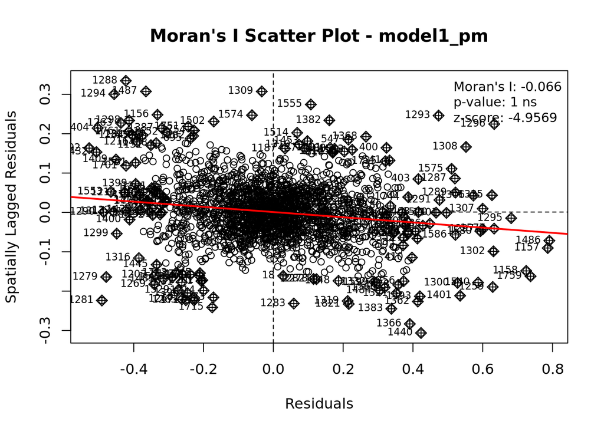

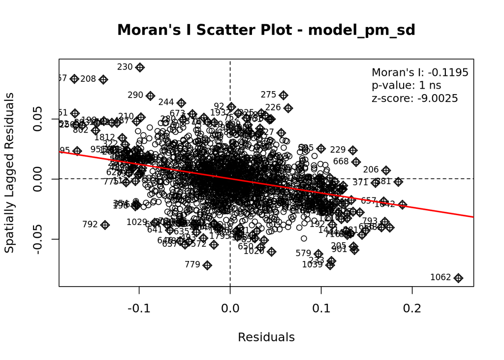

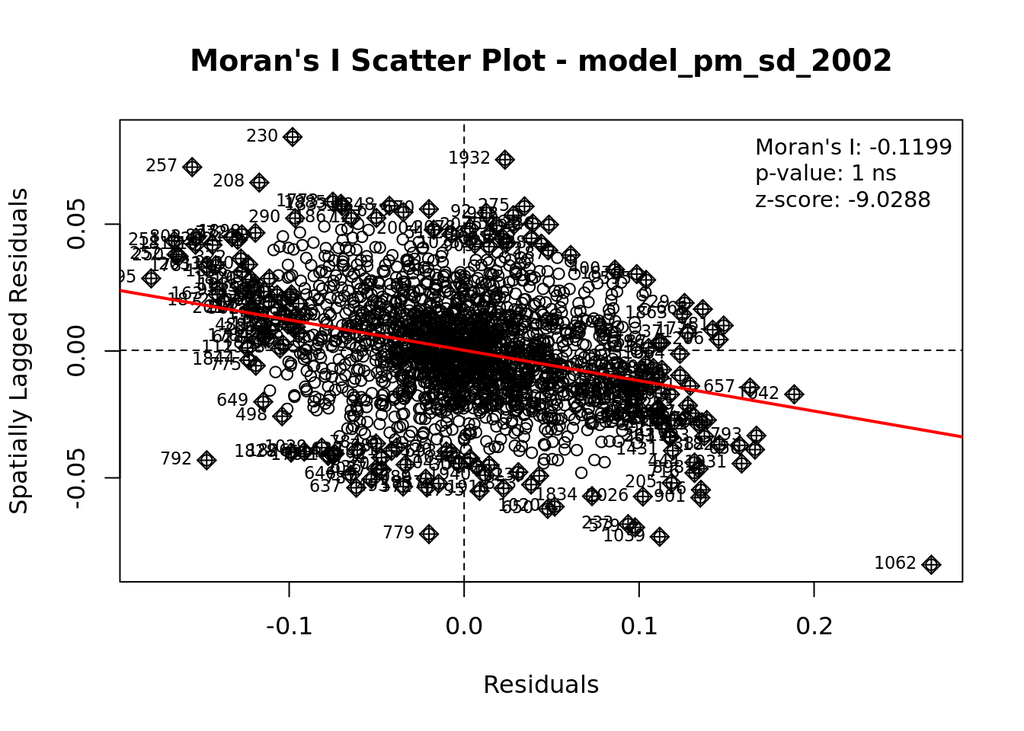

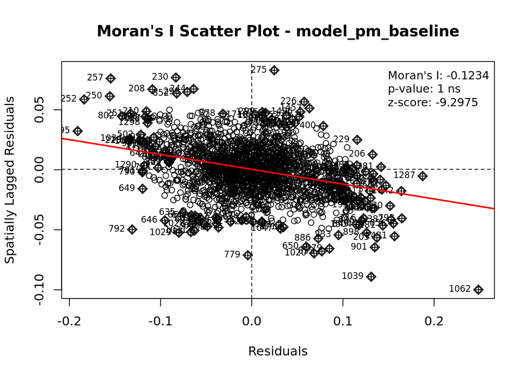

```r
knitr::kable(pm_morans, caption = "Moran's I Results for PM Models")
```

Moran’s I Results for PM Models

|  | model | morans_i | p_value | z_score | significance |
| --- | --- | --- | --- | --- | --- |
| Moran I statistic | model1_pm | -0.0660 | 0.9999996 | -4.9569 | ns |
| Moran I statistic1 | model_pm_sd | -0.1195 | 1.0000000 | -9.0025 | ns |
| Moran I statistic2 | model_pm_sd_2002 | -0.1199 | 1.0000000 | -9.0288 | ns |
| Moran I statistic3 | model_pm_baseline | -0.1234 | 1.0000000 | -9.2975 | ns |

```r
# O3 models
cat("## Moran's I Analysis for O3 Models\n")
```

```
## ## Moran's I Analysis for O3 Models
```

```r
o3_morans <- analyze_spatial_autocorrelation(
  o3_models,
  o3_names,
  all_data_inc$o3_change,
  Locations,
  k = 5
)
```

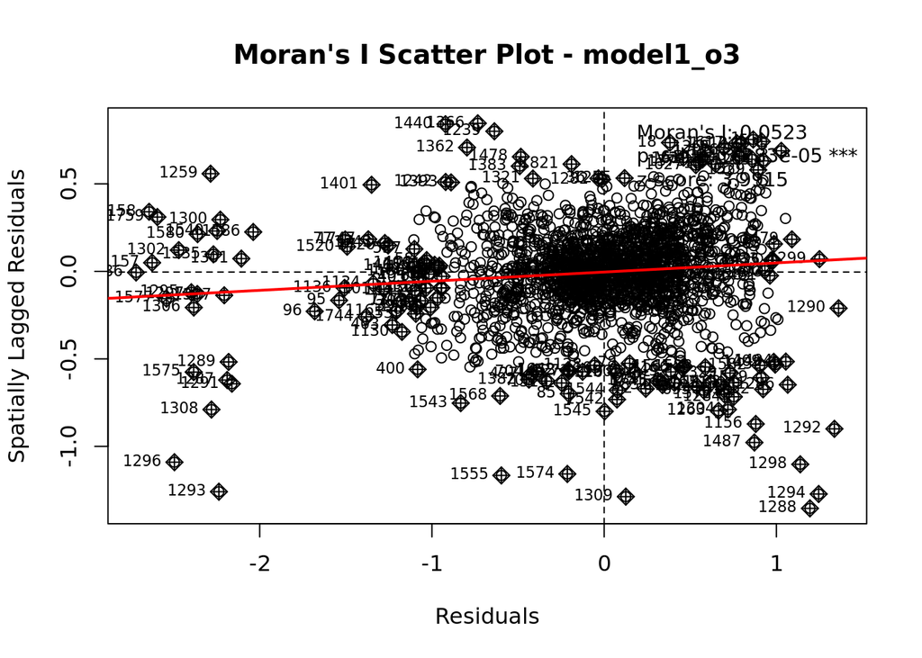

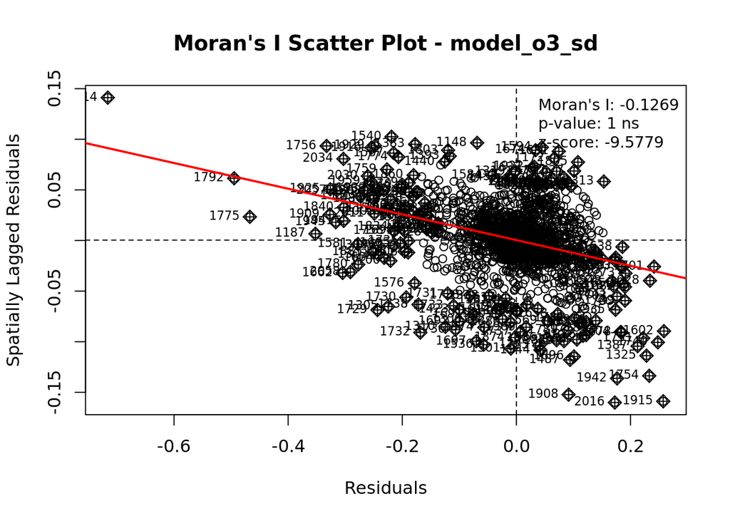

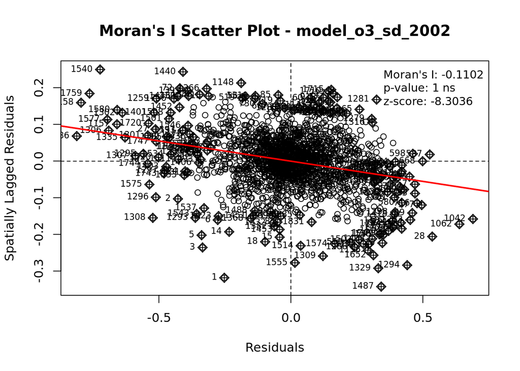

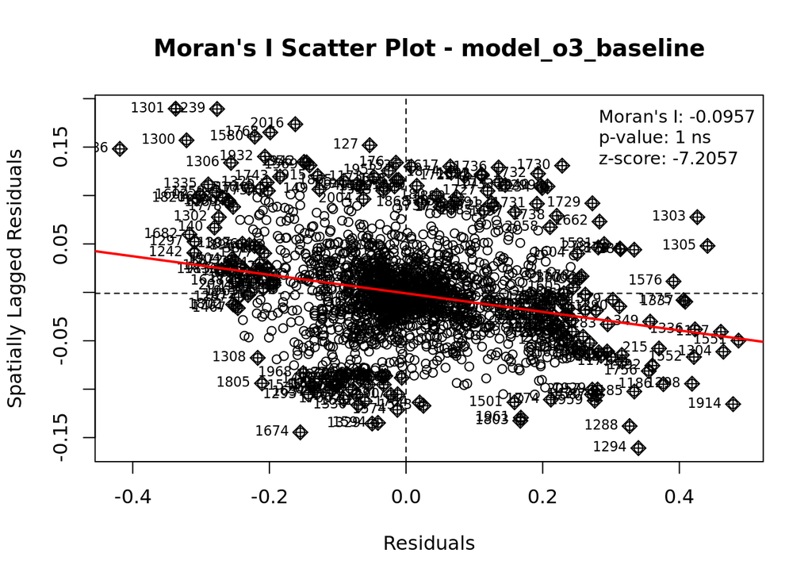

```r
knitr::kable(o3_morans, caption = "Moran's I Results for O3 Models")
```

Moran’s I Results for O3 Models

|  | model | morans_i | p_value | z_score | significance |
| --- | --- | --- | --- | --- | --- |
| Moran I statistic | model1_o3 | 0.0523 | 3.28e-05 | 3.9915 | *** |
| Moran I statistic1 | model_o3_sd | -0.1269 | 1.00e+00 | -9.5779 | ns |
| Moran I statistic2 | model_o3_sd_2002 | -0.1102 | 1.00e+00 | -8.3036 | ns |
| Moran I statistic3 | model_o3_baseline | -0.0957 | 1.00e+00 | -7.2057 | ns |

```r
# NO2 models
cat("## Moran's I Analysis for NO2 Models\n")
```

```
## ## Moran's I Analysis for NO2 Models
```

```r
no2_morans <- analyze_spatial_autocorrelation(
  no2_models,
  no2_names,
  all_data_inc$no2_change,
  Locations,
  k = 5
)
```

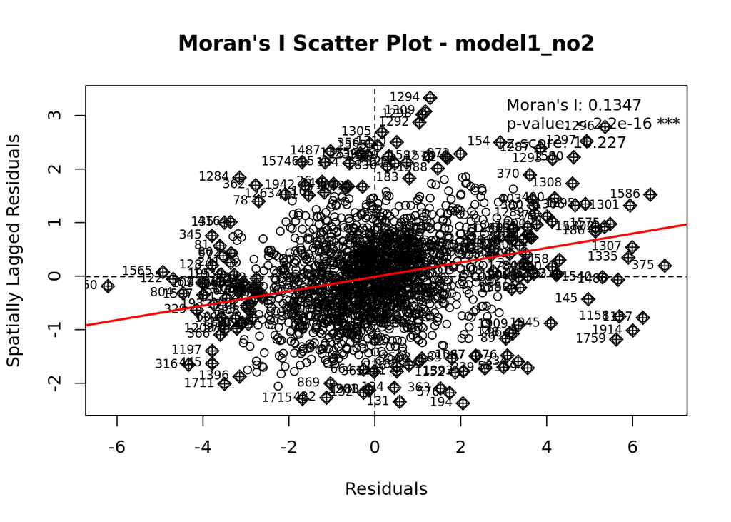

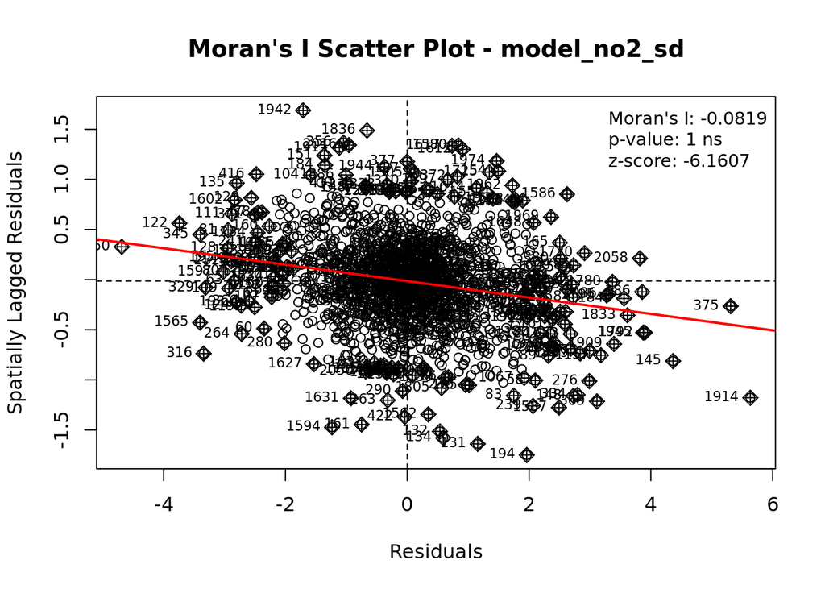

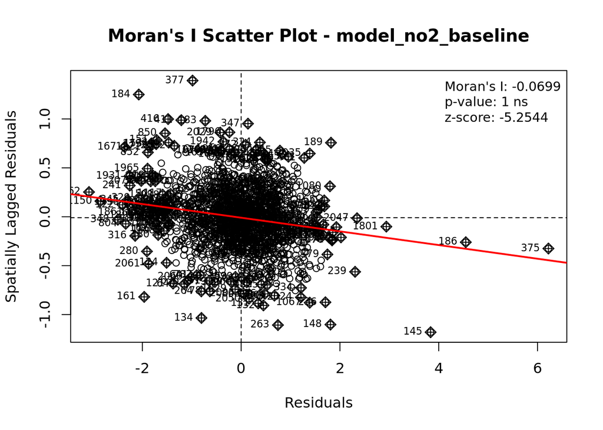

```r
knitr::kable(no2_morans, caption = "Moran's I Results for NO2 Models")
```

Moran’s I Results for NO2 Models

|  | model | morans_i | p_value | z_score | significance |
| --- | --- | --- | --- | --- | --- |
| Moran I statistic | model1_no2 | 0.1347 | 0.0000000 | 10.2270 | *** |
| Moran I statistic1 | model_no2_sd | -0.0819 | 1.0000000 | -6.1607 | ns |
| Moran I statistic2 | model_no2_baseline | -0.0699 | 0.9999999 | -5.2544 | ns |

```r
# NDVI models
cat("## Moran's I Analysis for NDVI Models\n")
```

```
## ## Moran's I Analysis for NDVI Models
```

```r
ndvi_morans <- analyze_spatial_autocorrelation(
  ndvi_models,
  ndvi_names,
  all_data_inc$ndvi_change,
  Locations,
  k = 5
)
```

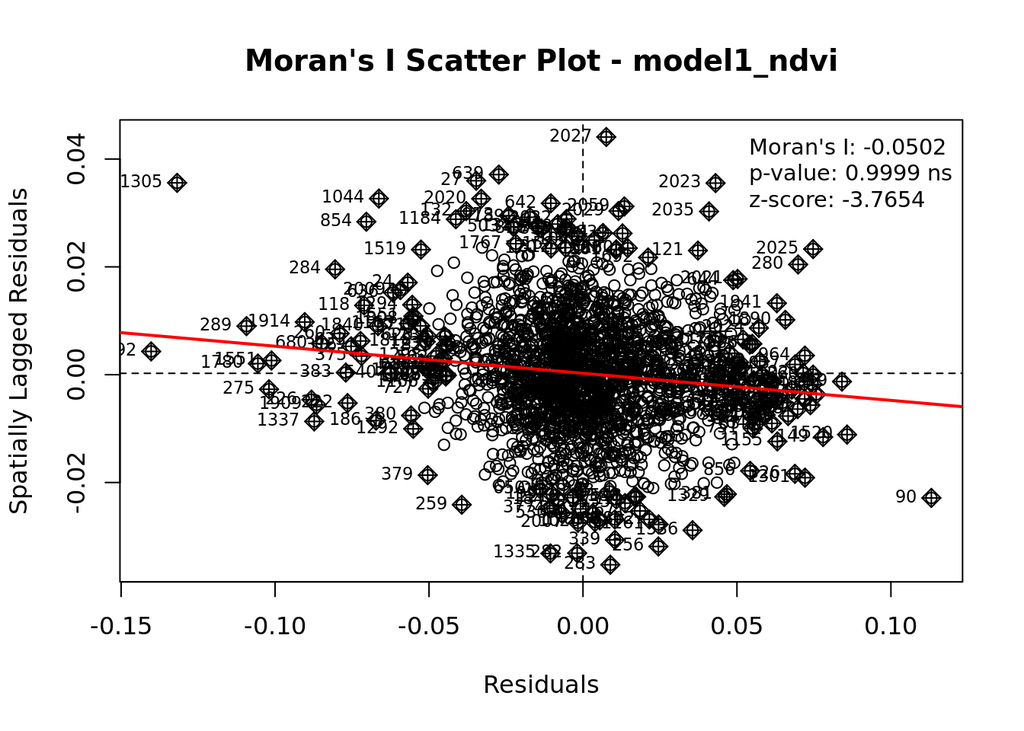

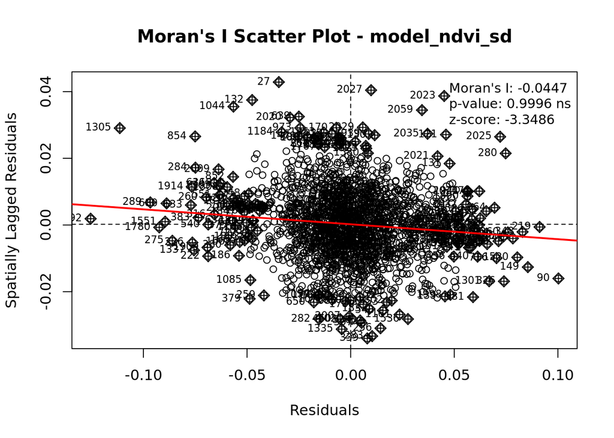

```r
knitr::kable(ndvi_morans, caption = "Moran's I Results for NDVI Models")
```

Moran’s I Results for NDVI Models

|  | model | morans_i | p_value | z_score | significance |
| --- | --- | --- | --- | --- | --- |
| Moran I statistic | model1_ndvi | -0.0502 | 0.9999168 | -3.7654 | ns |
| Moran I statistic1 | model_ndvi_sd | -0.0447 | 0.9995939 | -3.3486 | ns |

```r
# Temperature models
cat("## Moran's I Analysis for Temperature Models\n")
```

```
## ## Moran's I Analysis for Temperature Models
```

```r
temp_morans <- analyze_spatial_autocorrelation(
  temp_models,
  temp_names,
  all_data_inc$mean_temp,
  Locations,
  k = 5
)
```

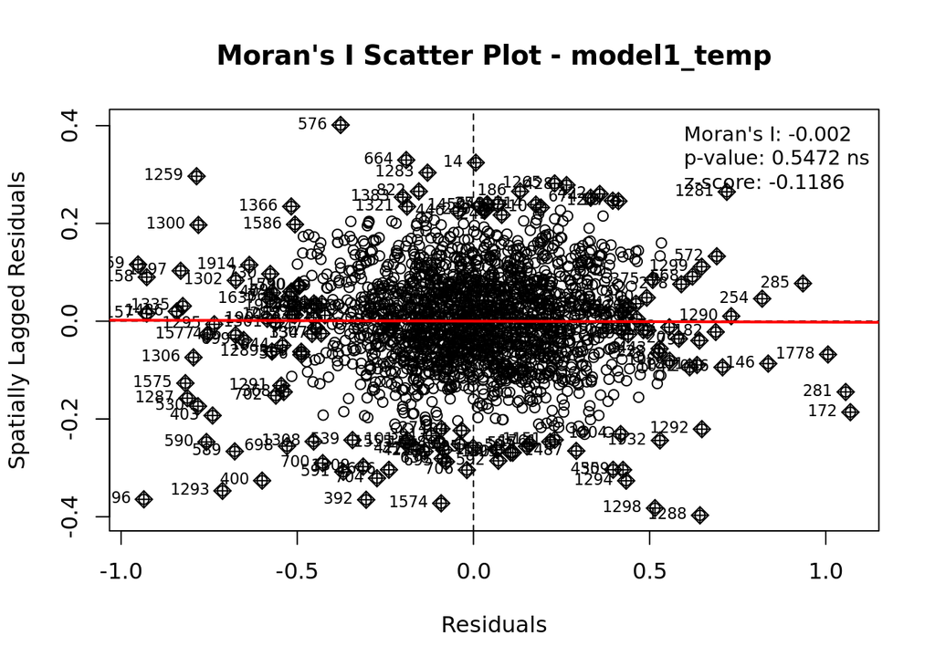

```r
knitr::kable(temp_morans, caption = "Moran's I Results for Temperature Models")
```

Moran’s I Results for Temperature Models

|  | model | morans_i | p_value | z_score | significance |
| --- | --- | --- | --- | --- | --- |
| Moran I statistic | model1_temp | -0.002 | 0.547198 | -0.1186 | ns |

```r
# Create summary of all results
cat("## Combined Moran's I Results for All Models\n")
```

```
## ## Combined Moran's I Results for All Models
```

```r
all_morans_summary <- create_morans_summary(
  list(pm_morans, o3_morans, no2_morans, ndvi_morans, temp_morans),
  c("PM", "O3", "NO2", "NDVI", "Temperature")
)
knitr::kable(all_morans_summary, caption = "Combined Moran's I Results")
```

Combined Moran’s I Results

|  | model_type | model | morans_i | p_value | z_score | significance |
| --- | --- | --- | --- | --- | --- | --- |
| Moran I statistic | PM | model1_pm | -0.0660 | 0.9999996 | -4.9569 | ns |
| Moran I statistic1 | PM | model_pm_sd | -0.1195 | 1.0000000 | -9.0025 | ns |
| Moran I statistic2 | PM | model_pm_sd_2002 | -0.1199 | 1.0000000 | -9.0288 | ns |
| Moran I statistic3 | PM | model_pm_baseline | -0.1234 | 1.0000000 | -9.2975 | ns |
| Moran I statistic4 | O3 | model1_o3 | 0.0523 | 0.0000328 | 3.9915 | *** |
| Moran I statistic11 | O3 | model_o3_sd | -0.1269 | 1.0000000 | -9.5779 | ns |
| Moran I statistic21 | O3 | model_o3_sd_2002 | -0.1102 | 1.0000000 | -8.3036 | ns |
| Moran I statistic31 | O3 | model_o3_baseline | -0.0957 | 1.0000000 | -7.2057 | ns |
| Moran I statistic5 | NO2 | model1_no2 | 0.1347 | 0.0000000 | 10.2270 | *** |
| Moran I statistic12 | NO2 | model_no2_sd | -0.0819 | 1.0000000 | -6.1607 | ns |
| Moran I statistic22 | NO2 | model_no2_baseline | -0.0699 | 0.9999999 | -5.2544 | ns |
| Moran I statistic6 | NDVI | model1_ndvi | -0.0502 | 0.9999168 | -3.7654 | ns |
| Moran I statistic13 | NDVI | model_ndvi_sd | -0.0447 | 0.9995939 | -3.3486 | ns |
| Moran I statistic7 | Temperature | model1_temp | -0.0020 | 0.5471980 | -0.1186 | ns |

```r
# Get model results for comparison
cat("## INLA Model Results\n")
```

```
## ## INLA Model Results
```

```r
# PM models
cat("### PM Models Comparison\n")
```

```
## ### PM Models Comparison
```

```r
pm_results <- compare_models(pm_models, pm_names)
# Display fixed effects table
fixed_effects_pm <- create_comparison_table(
  lapply(pm_results, function(x) x$fixed_summary),
  pm_names,
  "Fixed Effects"
)
knitr::kable(fixed_effects_pm, caption = "PM Models - Fixed Effects")
```

PM Models - Fixed Effects

| Parameter | model1_pm_mean | model1_pm_sd | model1_pm_0.025quant | model1_pm_0.5quant | model1_pm_0.975quant | model1_pm_mode | model1_pm_kld | model_pm_sd_mean | model_pm_sd_sd | model_pm_sd_0.025quant | model_pm_sd_0.5quant | model_pm_sd_0.975quant | model_pm_sd_mode | model_pm_sd_kld | model_pm_sd_2002_mean | model_pm_sd_2002_sd | model_pm_sd_2002_0.025quant | model_pm_sd_2002_0.5quant | model_pm_sd_2002_0.975quant | model_pm_sd_2002_mode | model_pm_sd_2002_kld | model_pm_baseline_mean | model_pm_baseline_sd | model_pm_baseline_0.025quant | model_pm_baseline_0.5quant | model_pm_baseline_0.975quant | model_pm_baseline_mode | model_pm_baseline_kld |
| --- | --- | --- | --- | --- | --- | --- | --- | --- | --- | --- | --- | --- | --- | --- | --- | --- | --- | --- | --- | --- | --- | --- | --- | --- | --- | --- | --- | --- |
| Intercept | -5.976 | 0.148 | -6.274 | -5.976 | -5.676 | -5.976 | 0 | 7.979 | 0.143 | 7.695 | 7.979 | 8.261 | 7.980 | 0 | 7.900 | 0.140 | 7.625 | 7.900 | 8.175 | 7.900 | 0 | 3.158 | 0.131 | 2.898 | 3.158 | 3.416 | 3.158 | 0 |
| score_0.5 | -0.089 | 0.005 | -0.099 | -0.089 | -0.080 | -0.089 | 0 | -0.025 | 0.002 | -0.028 | -0.025 | -0.022 | -0.025 | 0 | -0.028 | 0.002 | -0.031 | -0.028 | -0.024 | -0.028 | 0 | -0.024 | 0.002 | -0.028 | -0.024 | -0.020 | -0.024 | 0 |
| med_income_decile | 0.007 | 0.002 | 0.004 | 0.007 | 0.011 | 0.007 | 0 | 0.003 | 0.001 | 0.002 | 0.003 | 0.005 | 0.003 | 0 | 0.003 | 0.001 | 0.002 | 0.003 | 0.004 | 0.003 | 0 | 0.003 | 0.001 | 0.002 | 0.003 | 0.005 | 0.003 | 0 |
| pm_sd_2002 | NA | NA | NA | NA | NA | NA | NA | -1.894 | 0.030 | -1.953 | -1.894 | -1.835 | -1.894 | 0 | -1.507 | 0.012 | -1.530 | -1.507 | -1.483 | -1.507 | 0 | NA | NA | NA | NA | NA | NA | NA |
| pm_sd_2016 | NA | NA | NA | NA | NA | NA | NA | 0.835 | 0.060 | 0.718 | 0.835 | 0.952 | 0.835 | 0 | NA | NA | NA | NA | NA | NA | NA | NA | NA | NA | NA | NA | NA | NA |
| pm_mean_2002 | NA | NA | NA | NA | NA | NA | NA | NA | NA | NA | NA | NA | NA | NA | NA | NA | NA | NA | NA | NA | NA | -0.632 | 0.005 | -0.643 | -0.632 | -0.622 | -0.632 | 0 |

```r
# O3 models
cat("### O3 Models Comparison\n")
```

```
## ### O3 Models Comparison
```

```r
o3_results <- compare_models(o3_models, o3_names)
# Display fixed effects table
fixed_effects_o3 <- create_comparison_table(
  lapply(o3_results, function(x) x$fixed_summary),
  o3_names,
  "Fixed Effects"
)
knitr::kable(fixed_effects_o3, caption = "O3 Models - Fixed Effects")
```

O3 Models - Fixed Effects

| Parameter | model1_o3_mean | model1_o3_sd | model1_o3_0.025quant | model1_o3_0.5quant | model1_o3_0.975quant | model1_o3_mode | model1_o3_kld | model_o3_sd_mean | model_o3_sd_sd | model_o3_sd_0.025quant | model_o3_sd_0.5quant | model_o3_sd_0.975quant | model_o3_sd_mode | model_o3_sd_kld | model_o3_sd_2002_mean | model_o3_sd_2002_sd | model_o3_sd_2002_0.025quant | model_o3_sd_2002_0.5quant | model_o3_sd_2002_0.975quant | model_o3_sd_2002_mode | model_o3_sd_2002_kld | model_o3_baseline_mean | model_o3_baseline_sd | model_o3_baseline_0.025quant | model_o3_baseline_0.5quant | model_o3_baseline_0.975quant | model_o3_baseline_mode | model_o3_baseline_kld |
| --- | --- | --- | --- | --- | --- | --- | --- | --- | --- | --- | --- | --- | --- | --- | --- | --- | --- | --- | --- | --- | --- | --- | --- | --- | --- | --- | --- | --- |
| Intercept | 2.540 | 0.482 | 1.516 | 2.542 | 3.551 | 2.543 | 0 | 4.729 | 0.679 | 3.399 | 4.727 | 6.065 | 4.724 | 0 | 62.323 | 0.790 | 60.774 | 62.321 | 63.877 | 62.318 | 0 | 21.845 | 0.168 | 21.513 | 21.846 | 22.175 | 21.846 | 0 |
| score_0.5 | 0.154 | 0.012 | 0.130 | 0.154 | 0.179 | 0.154 | 0 | 0.010 | 0.003 | 0.005 | 0.010 | 0.016 | 0.010 | 0 | 0.023 | 0.006 | 0.010 | 0.023 | 0.035 | 0.023 | 0 | -0.025 | 0.004 | -0.032 | -0.025 | -0.018 | -0.025 | 0 |
| med_income_decile | -0.014 | 0.005 | -0.024 | -0.014 | -0.004 | -0.014 | 0 | -0.013 | 0.001 | -0.015 | -0.013 | -0.011 | -0.013 | 0 | -0.008 | 0.002 | -0.013 | -0.008 | -0.004 | -0.008 | 0 | 0.004 | 0.001 | 0.001 | 0.004 | 0.007 | 0.004 | 0 |
| o3_sd_2002 | NA | NA | NA | NA | NA | NA | NA | -1.625 | 0.021 | -1.666 | -1.625 | -1.584 | -1.625 | 0 | -2.997 | 0.036 | -3.069 | -2.997 | -2.926 | -2.997 | 0 | NA | NA | NA | NA | NA | NA | NA |
| o3_sd_2016 | NA | NA | NA | NA | NA | NA | NA | 2.182 | 0.024 | 2.135 | 2.182 | 2.228 | 2.182 | 0 | NA | NA | NA | NA | NA | NA | NA | NA | NA | NA | NA | NA | NA | NA |
| o3_mean_2002 | NA | NA | NA | NA | NA | NA | NA | NA | NA | NA | NA | NA | NA | NA | NA | NA | NA | NA | NA | NA | NA | -0.594 | 0.004 | -0.602 | -0.594 | -0.587 | -0.594 | 0 |

```r
# NO2 models
cat("### NO2 Models Comparison\n")
```

```
## ### NO2 Models Comparison
```

```r
no2_results <- compare_models(no2_models, no2_names)
# Display fixed effects table
fixed_effects_no2 <- create_comparison_table(
  lapply(no2_results, function(x) x$fixed_summary),
  no2_names,
  "Fixed Effects"
)
knitr::kable(fixed_effects_no2, caption = "NO2 Models - Fixed Effects")
```

NO2 Models - Fixed Effects

| Parameter | model1_no2_mean | model1_no2_sd | model1_no2_0.025quant | model1_no2_0.5quant | model1_no2_0.975quant | model1_no2_mode | model1_no2_kld | model_no2_sd_mean | model_no2_sd_sd | model_no2_sd_0.025quant | model_no2_sd_0.5quant | model_no2_sd_0.975quant | model_no2_sd_mode | model_no2_sd_kld | model_no2_baseline_mean | model_no2_baseline_sd | model_no2_baseline_0.025quant | model_no2_baseline_0.5quant | model_no2_baseline_0.975quant | model_no2_baseline_mode | model_no2_baseline_kld |
| --- | --- | --- | --- | --- | --- | --- | --- | --- | --- | --- | --- | --- | --- | --- | --- | --- | --- | --- | --- | --- | --- |
| Intercept | -14.269 | 0.578 | -15.402 | -14.270 | -13.133 | -14.270 | 0 | -16.436 | 7.969 | -32.098 | -16.431 | -0.812 | -16.422 | 0 | -0.776 | 0.534 | -1.859 | -0.773 | 0.293 | -0.766 | 0 |
| score_0.5 | -0.418 | 0.035 | -0.487 | -0.418 | -0.350 | -0.418 | 0 | -0.247 | 0.033 | -0.313 | -0.247 | -0.182 | -0.247 | 0 | -0.153 | 0.023 | -0.197 | -0.153 | -0.108 | -0.153 | 0 |
| med_income_decile | -0.089 | 0.014 | -0.116 | -0.089 | -0.062 | -0.089 | 0 | -0.088 | 0.013 | -0.114 | -0.088 | -0.063 | -0.088 | 0 | -0.111 | 0.009 | -0.129 | -0.111 | -0.094 | -0.111 | 0 |
| o3_sd_2002 | NA | NA | NA | NA | NA | NA | NA | 1.766 | 0.247 | 1.281 | 1.765 | 2.251 | 1.765 | 0 | NA | NA | NA | NA | NA | NA | NA |
| o3_sd_2016 | NA | NA | NA | NA | NA | NA | NA | -2.388 | 0.276 | -2.929 | -2.388 | -1.847 | -2.388 | 0 | NA | NA | NA | NA | NA | NA | NA |
| no2_2000 | NA | NA | NA | NA | NA | NA | NA | NA | NA | NA | NA | NA | NA | NA | -0.421 | 0.008 | -0.435 | -0.421 | -0.406 | -0.421 | 0 |

```r
# NDVI models
cat("### NDVI Models Comparison\n")
```

```
## ### NDVI Models Comparison
```

```r
ndvi_results <- compare_models(ndvi_models, ndvi_names)
# Display fixed effects table
fixed_effects_ndvi <- create_comparison_table(
  lapply(ndvi_results, function(x) x$fixed_summary),
  ndvi_names,
  "Fixed Effects"
)
knitr::kable(fixed_effects_ndvi, caption = "NDVI Models - Fixed Effects")
```

NDVI Models - Fixed Effects

| Parameter | model1_ndvi_mean | model1_ndvi_sd | model1_ndvi_0.025quant | model1_ndvi_0.5quant | model1_ndvi_0.975quant | model1_ndvi_mode | model1_ndvi_kld | model_ndvi_sd_mean | model_ndvi_sd_sd | model_ndvi_sd_0.025quant | model_ndvi_sd_0.5quant | model_ndvi_sd_0.975quant | model_ndvi_sd_mode | model_ndvi_sd_kld |
| --- | --- | --- | --- | --- | --- | --- | --- | --- | --- | --- | --- | --- | --- | --- |
| Intercept | 0.025 | 0.008 | 0.009 | 0.025 | 0.042 | 0.025 | 0 | 0.012 | 0.011 | -0.010 | 0.012 | 0.035 | 0.012 | 0 |
| score_0.5 | 0.000 | 0.001 | -0.001 | 0.000 | 0.001 | 0.000 | 0 | 0.000 | 0.001 | -0.001 | 0.000 | 0.001 | 0.000 | 0 |
| med_income_decile | 0.001 | 0.000 | 0.001 | 0.001 | 0.002 | 0.001 | 0 | 0.001 | 0.000 | 0.000 | 0.001 | 0.001 | 0.001 | 0 |
| ndvi_mean_2000 | NA | NA | NA | NA | NA | NA | NA | 0.069 | 0.007 | 0.056 | 0.069 | 0.083 | 0.069 | 0 |

```r
# Temperature models
cat("### Temperature Models Comparison\n")
```

```
## ### Temperature Models Comparison
```

```r
temp_results <- compare_models(temp_models, temp_names)
# Display fixed effects table
fixed_effects_temp <- create_comparison_table(
  lapply(temp_results, function(x) x$fixed_summary),
  temp_names,
  "Fixed Effects"
)
knitr::kable(fixed_effects_temp, caption = "Temperature Models - Fixed Effects")
```

Temperature Models - Fixed Effects

| Parameter | model1_temp_mean | model1_temp_sd | model1_temp_0.025quant | model1_temp_0.5quant | model1_temp_0.975quant | model1_temp_mode | model1_temp_kld |
| --- | --- | --- | --- | --- | --- | --- | --- |
| Intercept | 295.594 | 0.056 | 295.485 | 295.595 | 295.703 | 295.595 | 0 |
| score_0.5 | 0.054 | 0.006 | 0.042 | 0.054 | 0.066 | 0.054 | 0 |
| med_income_decile | -0.010 | 0.002 | -0.015 | -0.010 | -0.005 | -0.010 | 0 |

```r
# Show model diagnostics with QQ plots for one model from each category
cat("## Model Diagnostics with Fixed QQ Plots\n")
```

```
## ## Model Diagnostics with Fixed QQ Plots
```

```r
# PM Model Diagnostics
cat("### PM Model Diagnostics\n")
```

```
## ### PM Model Diagnostics
```

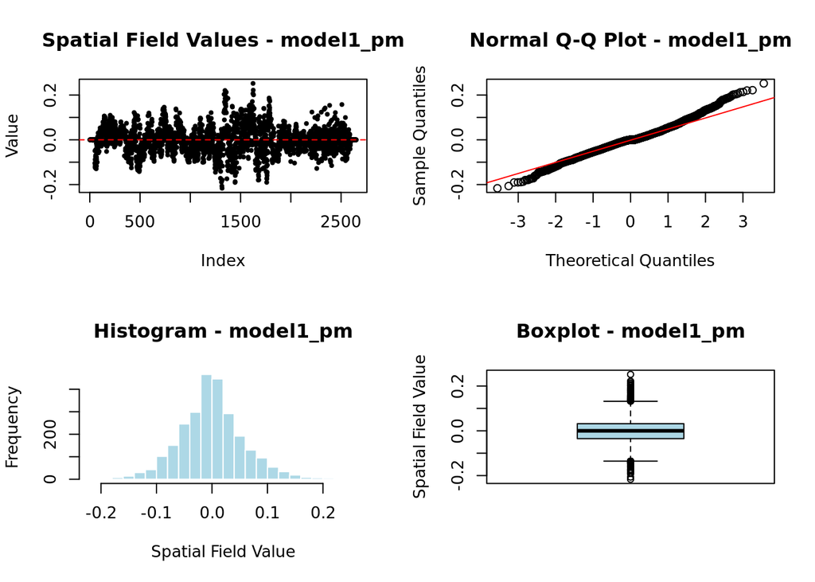

```r
if (!is.null(pm_models[[1]])) {
  plot_model_diagnostics(pm_models[[1]], pm_names[1])
}
```

```r
# O3 Model Diagnostics
cat("### O3 Model Diagnostics\n")
```

```
## ### O3 Model Diagnostics
```

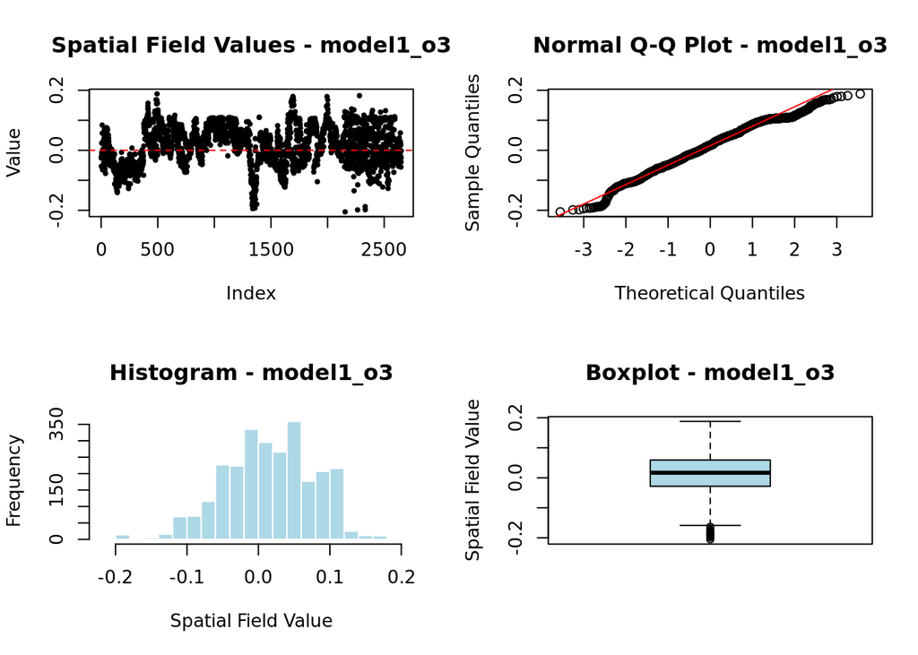

```r
if (!is.null(o3_models[[1]])) {
  plot_model_diagnostics(o3_models[[1]], o3_names[1])
}
```

```r
# NO2 Model Diagnostics
cat("### NO2 Model Diagnostics\n")
```

```
## ### NO2 Model Diagnostics
```

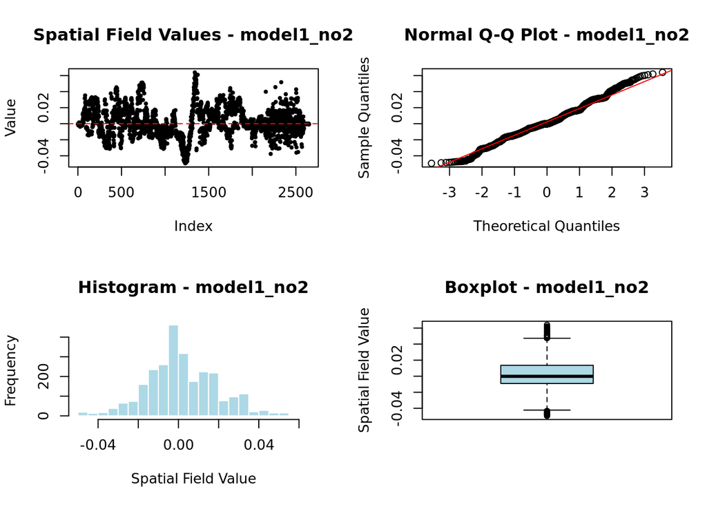

```r
if (!is.null(no2_models[[1]])) {
  plot_model_diagnostics(no2_models[[1]], no2_names[1])
}
```

```r
# NDVI Model Diagnostics
cat("### NDVI Model Diagnostics\n")
```

```
## ### NDVI Model Diagnostics
```

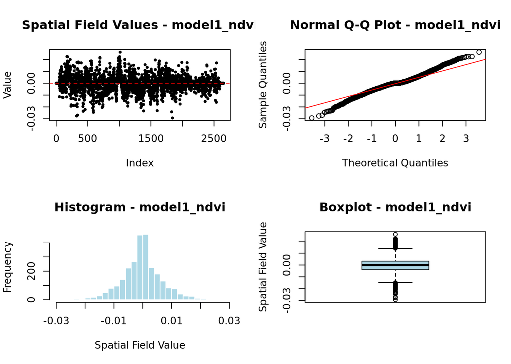

```r
if (!is.null(ndvi_models[[1]])) {
  plot_model_diagnostics(ndvi_models[[1]], ndvi_names[1])
}
```

```r
# Temperature Model Diagnostics
cat("### Temperature Model Diagnostics\n")
```

```
## ### Temperature Model Diagnostics
```

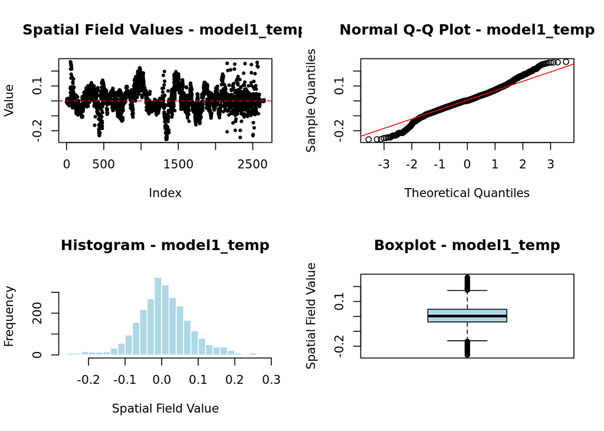

```r
if (!is.null(temp_models[[1]])) {
  plot_model_diagnostics(temp_models[[1]], temp_names[1])
}
```

```r
# Create DIC comparison table for all models
cat("## Model Comparison using DIC\n")
```

```
## ## Model Comparison using DIC
```

```r
model_comparison <- data.frame(
  Model_Type = character(),
  Model = character(),
  DIC = numeric(),
  stringsAsFactors = FALSE
)

# Add PM models
for (i in seq_along(pm_models)) {
  if (!is.null(pm_models[[i]]) && !is.null(pm_models[[i]]$dic)) {
    model_comparison <- rbind(model_comparison,
                             data.frame(
                               Model_Type = "PM",
                               Model = pm_names[i],
                               DIC = pm_models[[i]]$dic$dic,
                               stringsAsFactors = FALSE
                             ))
  }
}

# Add O3 models
for (i in seq_along(o3_models)) {
  if (!is.null(o3_models[[i]]) && !is.null(o3_models[[i]]$dic)) {
    model_comparison <- rbind(model_comparison,
                             data.frame(
                               Model_Type = "O3",
                               Model = o3_names[i],
                               DIC = o3_models[[i]]$dic$dic,
                               stringsAsFactors = FALSE
                             ))
  }
}

# Add NO2 models
for (i in seq_along(no2_models)) {
  if (!is.null(no2_models[[i]]) && !is.null(no2_models[[i]]$dic)) {
    model_comparison <- rbind(model_comparison,
                             data.frame(
                               Model_Type = "NO2",
                               Model = no2_names[i],
                               DIC = no2_models[[i]]$dic$dic,
                               stringsAsFactors = FALSE
                             ))
  }
}

# Add NDVI models
for (i in seq_along(ndvi_models)) {
  if (!is.null(ndvi_models[[i]]) && !is.null(ndvi_models[[i]]$dic)) {
    model_comparison <- rbind(model_comparison,
                             data.frame(
                               Model_Type = "NDVI",
                               Model = ndvi_names[i],
                               DIC = ndvi_models[[i]]$dic$dic,
                               stringsAsFactors = FALSE
                             ))
  }
}

# Add Temperature models
for (i in seq_along(temp_models)) {
  if (!is.null(temp_models[[i]]) && !is.null(temp_models[[i]]$dic)) {
    model_comparison <- rbind(model_comparison,
                             data.frame(
                               Model_Type = "Temperature",
                               Model = temp_names[i],
                               DIC = temp_models[[i]]$dic$dic,
                               stringsAsFactors = FALSE
                             ))
  }
}

# Display model comparison table
knitr::kable(model_comparison, caption = "Model Comparison by DIC")
```

Model Comparison by DIC

| Model_Type | Model | DIC |
| --- | --- | --- |
| PM | model1_pm | -716.46703 |
| PM | model_pm_sd | -5553.31702 |
| PM | model_pm_sd_2002 | -5381.21822 |
| PM | model_pm_baseline | -5171.03383 |
| O3 | model1_o3 | 3262.82282 |
| O3 | model_o3_sd | -3439.78586 |
| O3 | model_o3_sd_2002 | -86.88298 |
| O3 | model_o3_baseline | -2293.73196 |
| NO2 | model1_no2 | 7652.15377 |
| NO2 | model_no2_sd | 7079.04483 |
| NO2 | model_no2_baseline | 5525.01522 |
| NDVI | model1_ndvi | -8834.08732 |
| NDVI | model_ndvi_sd | -8932.91436 |
| Temperature | model1_temp | 237.09169 |